# Plant communities: structural stability and sign patterns of empirical interaction matrices

Author

Simon Frost

## Overview

Most resilience metrics need a model at an equilibrium: a Jacobian, which needs both the interaction coefficients and the growth rates. Empirical plant studies usually give only the first. This vignette asks what can still be said about stability from interaction matrices alone, using two published compilations:

- **Kinlock (2019):** 25 complete plant interaction networks (3–8 species), measured as relative interaction indices (RII) against monoculture controls;
- **Adler et al. (2018):** 39 complete competition-coefficient matrices (2–6 species) from 19 field and greenhouse studies.

Both datasets are CC0 and ship with the package (`data/kinlock2019`, `data/adler2018`).

Two kinds of analysis need no growth rates:

- **structural stability:** the share of growth-rate vectors for which all species can coexist (the feasibility domain; Saavedra et al. 2017);
- **sign patterns:** what the signs of the interactions alone imply for stability and for the response to a sustained press (Allesina & Pascual 2008; Dambacher et al. 2003).

```julia
using CommunityMatrices
using Random, Statistics, LinearAlgebra, Printf
using DataFrames
using Plots
data = joinpath(pkgdir(CommunityMatrices), "data")
kinlock = read_kinlock(joinpath(data, "kinlock2019", "Data_PlantInteractionNetworks.csv"))
adler = read_adler(joinpath(data, "adler2018", "CompetitionRegressionData071517.csv"))
(kinlock = length(kinlock), adler = length(adler), adler_studies = length(unique(x.study for x in adler)))
```

```
(kinlock = 25, adler = 39, adler_studies = 19)
```

## From published numbers to typed matrices

The two datasets record different quantities, and neither is a Lotka–Volterra coefficient matrix as published.

- **Kinlock** gives RII = (P_with − P_without)/(P_with + P_without) for each pair: a relative change in performance, bounded in [−1, 1], with a diagonal of 0 by construction. `alpha_from_rii` reads the RIIs as per-capita effects relative to a self-regulation of −1. This is an assumption, and the matrix records it.
- **Adler** gives competition coefficients whose sign convention varies by study. `read_adler` puts every study in the Lotka–Volterra convention (negative = competition), divides each row by its intraspecific coefficient so the diagonal is −1, and skips groups whose convention is free text or whose intraspecific coefficient is zero.

Neither dataset has growth rates, so both readers set `r = 1` and say so in the metadata.

```julia
K = [alpha_from_rii(n) for n in kinlock]
A = [x.alpha for x in adler]
a = K[16]                     # Pfeifer-Meister et al. 2008, four grassland species
println(kinlock[16].study, ": ", join(taxa(a), ", "))
display(round.(matrix(a); digits = 2))
println(matrix_metadata(a).derivation)
```

```
Pfeifer-Meister et al. 2008: Danthonia californica, Deschampsia cespitosa, Festuca arundinacea, Lolium multiflorum
Kinlock 2019 RII as per-capita effects × 1.0, diagonal −1; r unknown, set to 1
```

```
4×4 Matrix{Float64}:
 -1.0   -0.24   0.02  -0.2
 -0.01  -1.0   -0.08  -0.43
  0.13   0.07  -1.0   -0.43
  0.15   0.18   0.31  -1.0
```

The typed matrix keeps what kind of object it is. An `AlphaMatrix` is not a Jacobian: turning it into one (`jacobian(a)`) needs the abundances at equilibrium, and they need `r`.

| Quantity | Needs | Available here? |
| --- | --- | --- |
| feasibility domain Ω, structural vector | `A` | yes |
| quasi-sign-stability, press-response signs | signs of `A` | yes |
| equilibrium `N* = −A⁻¹r`, `isfeasible` | `A`, `r` | no: depends on the placeholder `r` |
| `feasibility_angle` | `A`, `r` | no |
| Jacobian `diag(N*) A` and every metric on it (resilience, reactivity, amplification) | `A`, `r` | no |

## Structural stability

For a Lotka–Volterra community `dNᵢ/dt = Nᵢ(rᵢ + Σⱼ Aᵢⱼ Nⱼ)`, all species coexist at an equilibrium when `N* = −A⁻¹r` is positive. The set of `r` for which this holds is a cone, the feasibility domain. Its size Ω is the fraction of random directions of `r` that fall inside it. `feasibility_domain` estimates Ω by Monte Carlo and also returns Ω^(1/S), which is comparable across community sizes: for `A = −I`, Ω^(1/S) = 1/2 at any S.

```julia
offdiag(M) = [M[i, j] for i in axes(M, 1), j in axes(M, 2) if i != j]
function summary_row(name, a)
    o = offdiag(matrix(a))
    fd = feasibility_domain(Xoshiro(2024), a; samples = 200_000)
    return (dataset = name, S = nspecies(a), Ω = fd.Ω, Ωs = fd.Ω_scaled, mean_effect = mean(o),
            competitive = mean(o .< 0))
end
tab = DataFrame(vcat([summary_row("Kinlock", a) for a in K], [summary_row("Adler", a) for a in A]))
combine(groupby(tab, :dataset), nrow => :n, :Ωs => median => :Ωs_median, :Ωs => minimum => :Ωs_min,
        :Ωs => maximum => :Ωs_max, :competitive => median => :competitive_share,
        [:mean_effect, :Ωs] => ((x, y) -> cor(x, y)) => :cor_effect_Ωs,
        [:S, :Ωs] => ((x, y) -> cor(x, y)) => :cor_S_Ωs)
```

2×8 DataFrame

| Row | dataset String | n Int64 | Ωs_median Float64 | Ωs_min Float64 | Ωs_max Float64 | competitive_share Float64 | cor_effect_Ωs Float64 | cor_S_Ωs Float64 |
| --- | --- | --- | --- | --- | --- | --- | --- | --- |
| 1 | Kinlock | 25 | 0.467477 | 0.0819036 | 0.699219 | 0.5 | 0.910411 | -0.0301104 |
| 2 | Adler | 39 | 0.265857 | 0.124826 | 0.629885 | 1.0 | 0.540815 | -0.208641 |

- **Kinlock communities have larger feasibility domains than Adler’s** (median Ω^(1/S) 0.47 against 0.27).
- **The mean interaction explains most of the difference.** Half of the Kinlock effects are facilitative, while Adler’s are, by selection, almost all competitive. Facilitation widens the feasibility cone and competition narrows it.
- **Richness barely matters once Ω is scaled.**

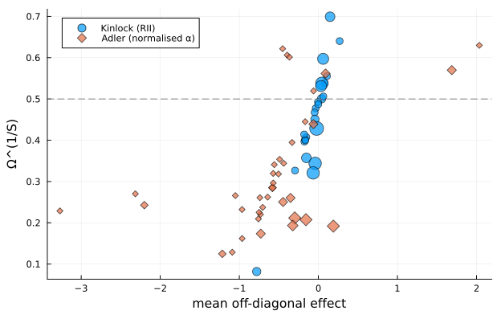

Figure 1: Scaled feasibility domain against the mean off-diagonal effect. The dashed line is Ω^(1/S) = 1/2, the value for non-interacting species.

```julia
p = plot(xlabel = "mean off-diagonal effect", ylabel = "Ω^(1/S)", legend = :topleft, size = (650, 420))
for (nm, m) in (("Kinlock (RII)", :circle), ("Adler (normalised α)", :diamond))
    d = tab[startswith.(nm, tab.dataset), :]
    scatter!(p, d.mean_effect, d.Ωs; label = nm, marker = m, markersize = 2 .+ d.S, alpha = 0.7)
end
hline!(p, [0.5]; ls = :dash, color = :gray, label = "")
p
```

## Against a null model

Is an observed community more structurally stable than other arrangements of the same interactions? The null keeps the diagonal and shuffles the observed off-diagonal effects among the off-diagonal positions. Each Ω is estimated from the same set of random directions (`Xoshiro(2024)`), so that observed and shuffled matrices are compared on common random numbers.

```julia
function shuffled(rng, a)
    M = copy(matrix(a))
    idx = [CartesianIndex(i, j) for i in axes(M, 1), j in axes(M, 2) if i != j]
    M[idx] = M[shuffle(rng, idx)]
    return AlphaMatrix(M, a.r)
end
pair = A[findfirst(a -> nspecies(a) == 2, A)]
Ωbig(a) = feasibility_domain(Xoshiro(7), a; samples = 2_000_000)
(observed = Ωbig(pair).Ω, transposed = Ωbig(AlphaMatrix(permutedims(matrix(pair)), pair.r)).Ω, se = Ωbig(pair).se)
```

```
(observed = 0.016342, transposed = 0.016525, se = 8.965193538345952e-5)
```

```julia
Ωcrn(a) = feasibility_domain(Xoshiro(2024), a; samples = 50_000).Ω_scaled
function percentile(rng, a; shuffles = 200)
    o = Ωcrn(a)
    null = [Ωcrn(shuffled(rng, a)) for _ in 1:shuffles]
    return mean(null .< o) + mean(null .== o) / 2
end
rng = Xoshiro(1)
tab.percentile = [percentile(rng, a) for a in vcat(K, A)]
big = tab[tab.S .>= 3, :]
combine(groupby(big, :dataset), nrow => :n, :percentile => median => :median_percentile,
        :percentile => (x -> count(>(0.5), x)) => :above_half)
```

2×4 DataFrame

| Row | dataset String | n Int64 | median_percentile Float64 | above_half Int64 |
| --- | --- | --- | --- | --- |
| 1 | Kinlock | 25 | 0.4825 | 12 |
| 2 | Adler | 14 | 0.4175 | 5 |

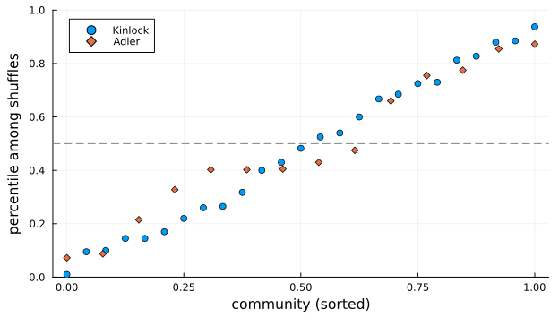

Figure 2: Percentile of each community’s Ω^(1/S) among 200 shuffles of its own off-diagonal effects (communities of three or more species). Above 0.5: more structurally stable than the shuffles.

```julia
q = plot(xlabel = "community (sorted)", ylabel = "percentile among shuffles", ylim = (0, 1),
         legend = :topleft, size = (650, 380))
for (nm, m) in (("Kinlock", :circle), ("Adler", :diamond))
    d = sort(big[big.dataset .== nm, :], :percentile)
    scatter!(q, range(0, 1; length = nrow(d)), d.percentile; label = nm, marker = m)
end
hline!(q, [0.5]; ls = :dash, color = :gray, label = "")
q
```

- **Observed plant communities are not more structurally stable than random arrangements of their own interactions.** The median percentile is 0.48 for Kinlock and 0.42 for Adler, and the communities are spread across almost the whole range.
- **What is arranged matters less than what there is.** The mean effect, which the shuffle keeps, sets Ω; the positions of the effects, which the shuffle changes, do not move it systematically.

## Sign patterns

The signs of a matrix alone constrain stability. `SignedDigraph` keeps only the signs, and the qualitative analyses draw random magnitudes uniform on (0, 1) for every non-zero entry, the diagonal included:

- `quasi_sign_stability`: the fraction of draws that are stable;
- `press_sign_determinacy`: among stable draws, the most common sign of each species’ response to a sustained increase in each species’ growth, and how often it occurs.

```julia
qrng = Xoshiro(3)
tab.qss = [quasi_sign_stability(qrng, SignedDigraph(a)).fraction for a in vcat(K, A)]
sort!(unstack(combine(groupby(tab, [:dataset, :S]), :qss => (x -> round(median(x); digits = 2)) => :qss_median),
              :S, :dataset, :qss_median), :S)
```

7×3 DataFrame

| Row | S Int64 | Kinlock Float64? | Adler Float64? |
| --- | --- | --- | --- |
| 1 | 2 | missing | 0.5 |
| 2 | 3 | 0.5 | 0.24 |
| 3 | 4 | 0.45 | 0.15 |
| 4 | 5 | 0.09 | 0.05 |
| 5 | 6 | 0.03 | 0.01 |
| 6 | 7 | 0.09 | missing |
| 7 | 8 | 0.16 | missing |

- **A competing pair is stable in exactly half of the draws.** With self-regulation dᵢ and competition cᵢⱼ all uniform on (0, 1), the pair is stable when d₁d₂ > c₁₂c₂₁, which by symmetry has probability 1/2. The 25 two-species Adler matrices sit there.
- **Larger communities are less often stable.** The median is 1/2 for Adler’s pairs and Kinlock’s three-species networks, and below 0.2 for five or more species in both datasets: each extra species adds feedback loops that a random draw can make destabilising.
- **The exceptions are always stable.** A few patterns have quasi-sign-stability 1. Either an interaction is missing and the effects run one way only (a zero coefficient in a pair), or each pair has opposite signs, like predator and prey.

For one community, the press analysis gives the response matrix and its determinacy:

```julia
s = SignedDigraph(a)
pr = press_sign_determinacy(Xoshiro(4), s; samples = 20_000)
println("stable draws: ", round(pr.stable; digits = 2))
genus = first.(split.(taxa(a)))
signs = DataFrame(pr.sign, Symbol.("press " .* genus))
insertcols!(signs, 1, :response => genus)
signs
```

```
stable draws: 0.45
```

4×5 DataFrame

| Row | response SubStrin… | press Danthonia Int8 | press Deschampsia Int8 | press Festuca Int8 | press Lolium Int8 |
| --- | --- | --- | --- | --- | --- |
| 1 | Danthonia | 1 | -1 | 1 | -1 |
| 2 | Deschampsia | -1 | 1 | -1 | 1 |
| 3 | Festuca | -1 | 1 | 1 | -1 |
| 4 | Lolium | 1 | 1 | 1 | 1 |

```julia
round.(pr.determinacy; digits = 2)
```

```
4×4 Matrix{Float64}:
 0.99  0.93  0.91  0.98
 0.93  0.99  0.98  0.91
 0.72  0.72  0.78  0.78
 0.74  0.75  0.74  0.77
```

- **Fewer than half of the random magnitudes give a stable community** with this sign pattern; the responses are computed over those.
- **Some responses are well determined.** The responses of *Danthonia* and *Deschampsia* have the same sign in more than 90% of the stable draws, whichever species is pressed.
- **Others are not, even to a species’ own press.** For *Festuca* and *Lolium* every response has a determinacy of about 0.75, including the response to an increase in their own growth: in a quarter of the stable draws, pressing one of them lowers its own abundance through indirect effects. A determinacy near 1/2 would mean the signs say nothing.

## What growth rates would add

The resilience metrics of the other vignettes are properties of the Jacobian at an equilibrium, and for a Lotka–Volterra community that is `diag(N*) A`, with `N* = −A⁻¹r`. Without `r`, the matrix fixes the cone of possible equilibria but not where in it the community sits. To see how much that matters, draw unit growth-rate vectors uniformly from the feasibility domain of the example community and compute the resilience of each resulting equilibrium.

```julia
function resilience_over_r(rng, a; n = 2_000)
    out = (resilience = Float64[], angle = Float64[])
    while length(out.resilience) < n
        r = normalize(randn(rng, nspecies(a)))
        b = AlphaMatrix(matrix(a), r)
        isfeasible(b) || continue
        push!(out.resilience, resilience(jacobian(b)))
        push!(out.angle, feasibility_angle(b))
    end
    return out
end
ro = resilience_over_r(Xoshiro(5), a)
(stable = mean(ro.resilience .> 0), quantiles = round.(quantile(ro.resilience, [0.05, 0.5, 0.95]); digits = 3),
 cor_angle = round(cor(ro.angle, ro.resilience); digits = 2))
```

```
(stable = 1.0, quantiles = [0.008, 0.103, 0.299], cor_angle = -0.76)
```

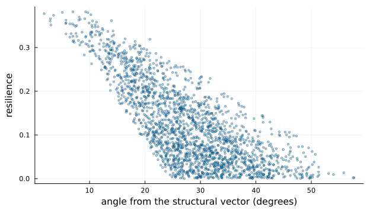

Figure 3: Resilience (the slowest return rate, −max Re λ) of the example community at equilibria drawn uniformly from its feasibility domain, against the angle between r and the structural vector.

```julia
scatter(ro.angle, ro.resilience; xlabel = "angle from the structural vector (degrees)",
        ylabel = "resilience", markersize = 2, alpha = 0.4, label = "", size = (650, 380))
```

- **Every feasible equilibrium of this community is stable**, so resilience is defined throughout its feasibility domain.
- **The same interaction matrix gives very different resilience.** Across feasible growth rates of unit length, the slowest return rate varies more than 30-fold between the 5th and 95th percentiles. (Resilience scales with the length of `r`, since `N*` does.)
- **Communities near the edge of their feasibility domain are the least resilient.** As `r` approaches a boundary of the cone, one species’ equilibrium abundance goes to zero, and with it the return rate along that direction.
- **So resilience is a property of a community at an equilibrium, not of its interaction matrix.** Structural stability and sign patterns are what a matrix without growth rates can support.

## Caveats

- **RII is not a per-capita coefficient.** Reading Kinlock’s RIIs as Lotka–Volterra effects relative to self-regulation −1 is an assumption; scaling them (`alpha_from_rii(net; scale)`) changes Ω.
- **Adler’s coefficients come from different response variables** (survival, growth, biomass, population growth), and are comparable only within a study.
- **The samples are small and selected.** Only complete matrices are used, which favours small communities: 14 of the 25 Kinlock networks have three species and 25 of the 39 Adler matrices have two.
- **Monte Carlo error.** Ω uses 2×10⁵ directions (5×10⁴ in the null comparison); the standard error is returned by `feasibility_domain`.

## References

- Adler, P. B. et al. (2018). Competition and coexistence in plant communities: intraspecific competition is stronger than interspecific competition. *Ecology Letters* 21:1319–1329. Data: doi:10.5061/dryad.q5mg97b (CC0).
- Allesina, S. & Pascual, M. (2008). Network structure, predator–prey modules, and stability in large food webs. *Theoretical Ecology* 1:55–64.
- Dambacher, J. M., Li, H. W. & Rossignol, P. A. (2003). Qualitative predictions in model ecosystems. *Ecological Modelling* 161:79–93.
- Kinlock, N. L. (2019). A meta-analysis of plant interaction networks reveals competitive hierarchies as well as facilitation and intransitivity. *American Naturalist* 194:640–653. Data: doi:10.5061/dryad.1sm06sp (CC0).
- Saavedra, S. et al. (2017). A structural approach for understanding multispecies coexistence. *Ecological Monographs* 87:470–486.